# Exercise 5

# Objectives

- Reinforce ggplot skills
- Use `patchwork` package to create a multiplot
- Save plots to file

## About the data

We’re going to look at the oysters in the “Saint Augustine” Region of the oyster monitoring effort and further examine spat abundance with environmental parameters over time. Once again the oyster data was collected by the Guana Tolomato Matanzas National Estuarine Research Reserve as part of an oyster monitoring pilot project led by Head Biologist Pamela Marcum. A report with this information can be found [here](https://gtmnerr.org/wp-content/uploads/2018/10/2014-2016-GTM-oyster-monitoring.pdf).

The water quality data comes from the System-Wide Monitoring Program (SWMP) water quality station at the mouth of the San Sebastian River in St. Augustine, Florida within the Guana Tolomato Matanzas National Estuarine Research Reserve. This data was collected using a continuous data sonde recording every 15-minutes from 2015-2020 and was aggregated to monthly values.

# A

Load your data. We’re going to read in the oyster length data, the spat count data, and the water quality data.

# B

We’ll also want to prep the `oysters` dataset to only contain the data in the Saint Augustine region, our region of interest. Run the code below.

Moving forward, we’ll be using this new `oysters2` df.

# C

- Create a density plot of Shell Height with vertical lines marking the upper limit of spat size (25 mm, dashed) and the lower limit of fishery-size (76mm).
- Set the axis text to be color = “black”, and the x and y labels as “Shell Height (mm)” and “Proportion”, respectively.
- Assign this plot to an object called “length_plot” (*Hint: use <-*)

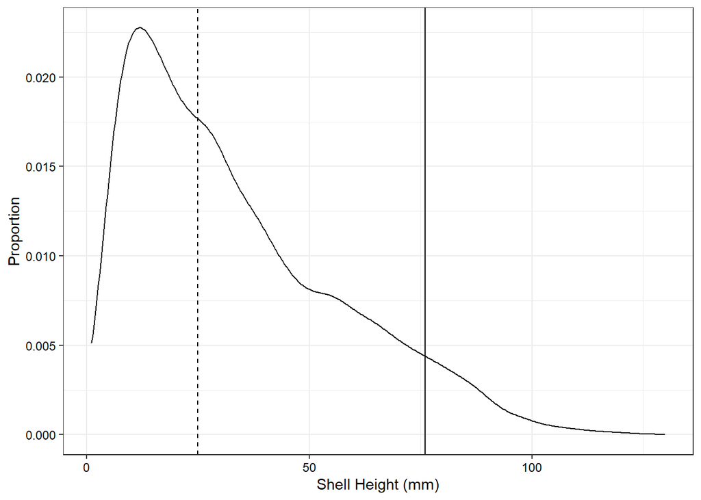

# D

Using the `spat` data, create a line graph of `spat_avg` over `deployment_date`.

- Update `scale_x_datetime` to include `date_breaks = "year"` and `date_labels = "%Y"`.
- Add the `theme_classic()` layer
- Set the axis text to be color = “black”, remove the x label, and change the y label to “Mean Spat per Shell”.
- Assign this plot to an object called “spat_plot” (*Hint: use <-*)

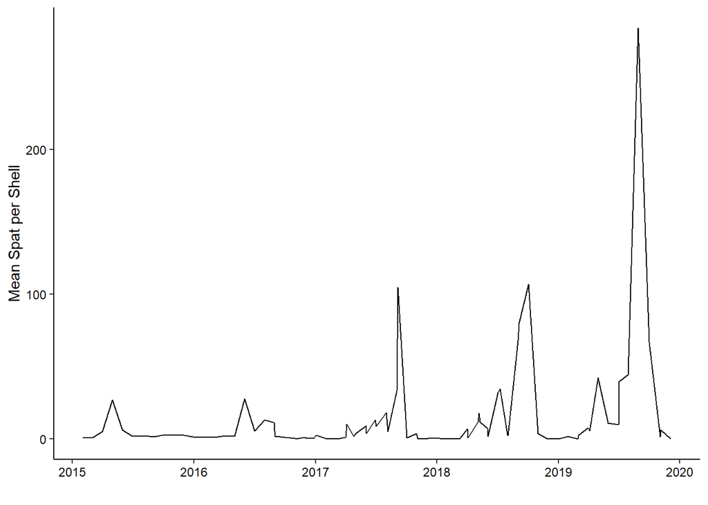

# E

Using the `ss_monthly_wq` data, create a line graph of `temp` over `datetimestamp`.

- Update `scale_x_date` to include `date_breaks = "year"` and `date_labels = "%Y"`. (**Note the change from _datetime. We are working with a “Date” class, not a “POSIXct” class which includes time**)
- Add the `theme_classic()` layer
- Set the axis text to be color = “black”, remove the x label, and change the y label to “Mean Monthly Temperature ( C)”. (The use of the U code allows for the addition of the degree symbol in the title!)
- Assign this plot to an object called “temp_plot” (*Hint: use <-*)

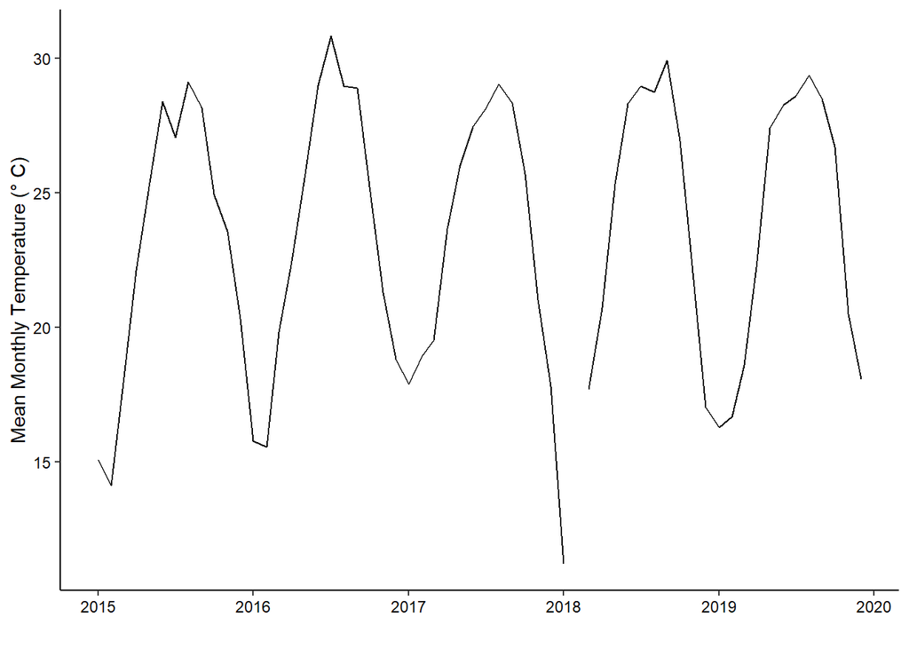

# F

Phew! Alright, now let’s get to the fun (and easy) part. The `patchwork` package makes creating multiplots as easy as basic math…because it’s like math!

Run the example I’ve included in the chunk below to see how just “adding” two plots together makes a multiplot of two plots side-by-side. After you do that, change the addition symbol to a forward slash as if you’re dividing, and notice how the plots change.

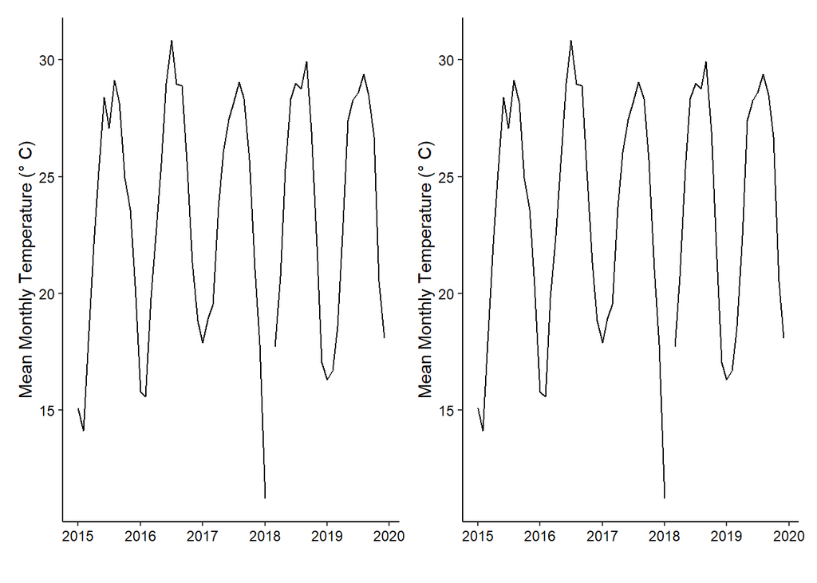

Remember PEMDAS from grade school? Anything inside of parentheses will be done first. So, examine the chunk below and run it. Try to guess what you will see before you run the code.

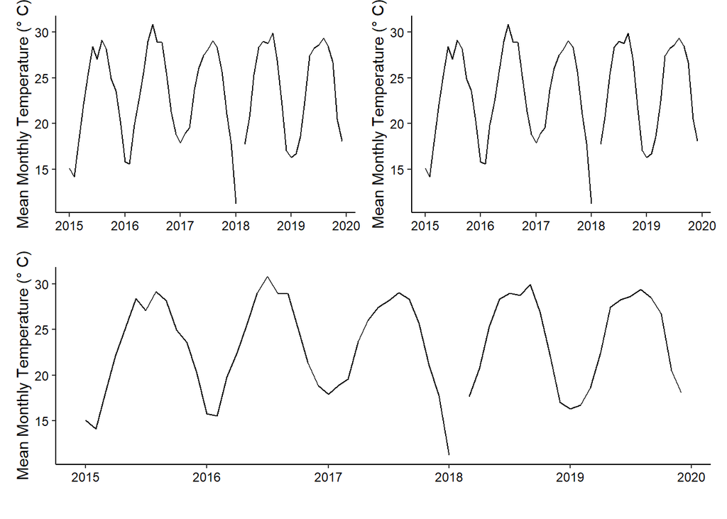

# G

Alright, after you get the hang of that, what we’re going to want to do is have the length plot on the lefthand side of our multiplot with the temp and spat plots stacked to it’s right. Check out the helper-file.html for this exercise to see what the final plot should look like.

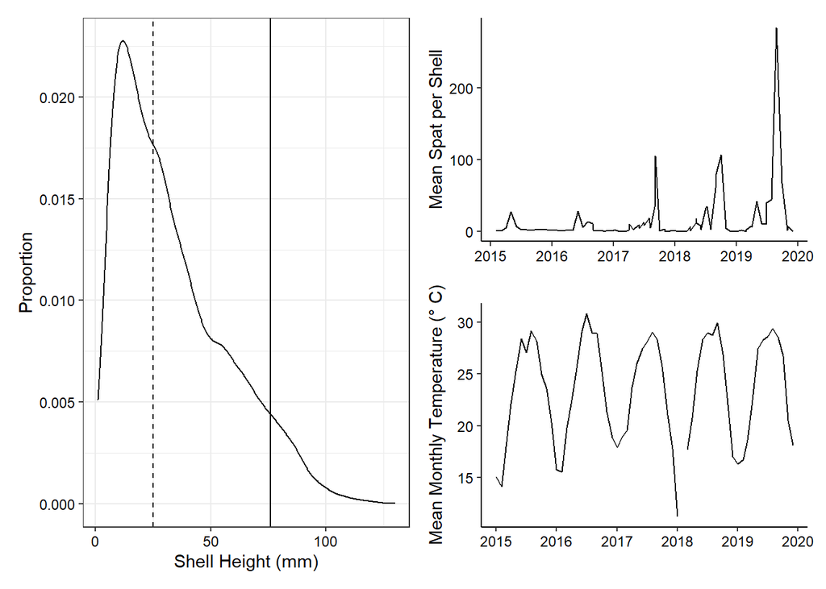

# H

Alright, once you have created your multiplot, let’s assign it to it’s own object called “multiplot” and save it to the ‘output’ subfolder in your main project folder.

How do you feel about multiplots now?